# Homework 2.1

#### Loading packages

```r
library(knitr)
library(gridExtra)
library(ggplot2)
library(car)
library(tseries)
library(lmtest)
diamonds <- read.table("HW-diamonds.txt", header=FALSE, col.names = c('caratage', 'color_purity', 'clarity', 'cert', 'price'))
```

## Caratage (Q1)

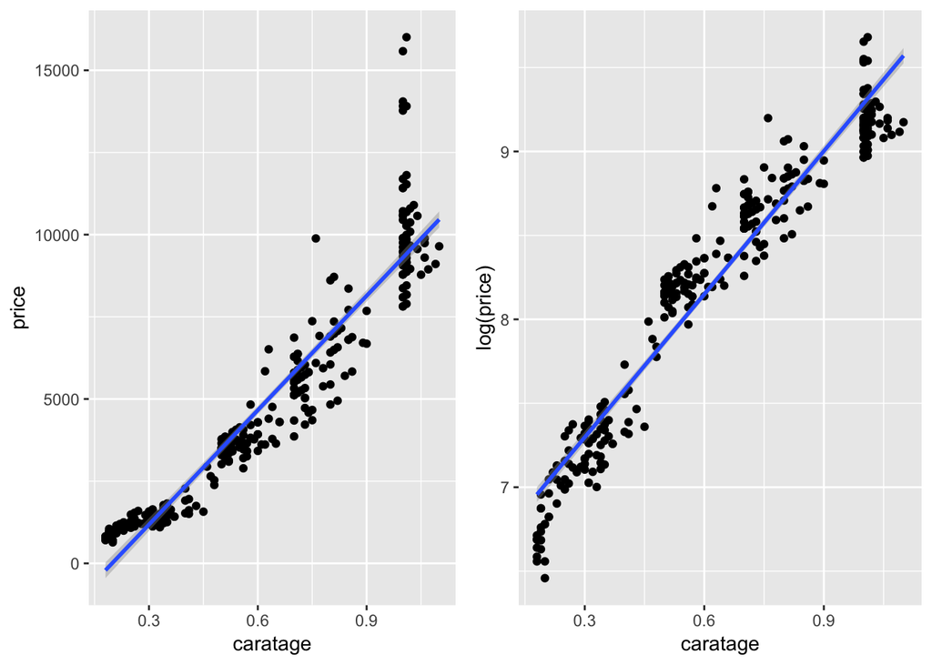

```r
G1 <- ggplot(diamonds, aes(x=caratage, y=price)) + geom_point() + geom_smooth(method = "lm")
G2 <- ggplot(diamonds, aes(x=caratage, y=log(price))) + geom_point() + geom_smooth(method = "lm")
grid.arrange(G1,G2,ncol=2)
```

From these plots it seems that there is a more linear relationship between caratage and log(price), than between caratage and price. Therefore, we choose to use log(price) as our response variable.

## Categorical information (Q2)

```r
# reorder
diamonds$color_purity = relevel(diamonds$color_purity, ref="I")
diamonds$clarity      = relevel(diamonds$clarity, ref="VS2")
diamonds$cert         = relevel(diamonds$cert, ref="HRD")

# fit model
lm1 = lm(formula = log(price) ~ caratage + color_purity + clarity + cert, data=diamonds)
summary(lm1)
```

```
##
## Call:
## lm(formula = log(price) ~ caratage + color_purity + clarity +
##     cert, data = diamonds)
##
## Residuals:
##      Min       1Q   Median       3Q      Max
## -0.31236 -0.11520  0.01613  0.10833  0.36339
##
## Coefficients:
##                Estimate Std. Error t value Pr(>|t|)
## (Intercept)    6.077239   0.048091 126.369  < 2e-16 ***
## caratage       2.855013   0.036968  77.230  < 2e-16 ***
## color_purityD  0.416557   0.041382  10.066  < 2e-16 ***
## color_purityE  0.387047   0.030824  12.557  < 2e-16 ***
## color_purityF  0.310198   0.027479  11.288  < 2e-16 ***
## color_purityG  0.210207   0.028359   7.412 1.32e-12 ***
## color_purityH  0.128681   0.028523   4.511 9.31e-06 ***
## clarityIF      0.298541   0.033303   8.964  < 2e-16 ***
## clarityVS1     0.096609   0.024919   3.877  0.00013 ***
## clarityVVS1    0.297835   0.028102  10.598  < 2e-16 ***
## clarityVVS2    0.201923   0.025344   7.967 3.56e-14 ***
## certGIA        0.008856   0.020864   0.424  0.67155
## certIGI       -0.173855   0.028673  -6.063 4.07e-09 ***
## ---
## Signif. codes:  0 '***' 0.001 '**' 0.01 '*' 0.05 '.' 0.1 ' ' 1
##
## Residual standard error: 0.1382 on 295 degrees of freedom
## Multiple R-squared:  0.9723, Adjusted R-squared:  0.9712
## F-statistic: 863.6 on 12 and 295 DF,  p-value: < 2.2e-16
```

### Interpretation of model fit

- Besides certGIA we find high significant net effects on all explenatory variables.
- One point increase in caratage increases the `log(price)` 2.855 times, everything else being the same. A 2.855 increase in `log(price)` is equivalent to a `exp(2.855) = 17.374` increase in price.
- Having color purity D increases the `log(price)` 0.42 times, compared to having color purity I, everything else being the same. A 0.417 increase in `log(price)` is equivalent to a `exp(0.417) = 1.517` increase in price.
- Having clarityVVS1 influences the price almost just as much as having clarityIF, everything else being equal.
- Having certIGI is worse for price than certHRD. Having certIGI compared to certHRD decreases the price `1 - exp(-0.174) = 0.160` times.

### Model plots

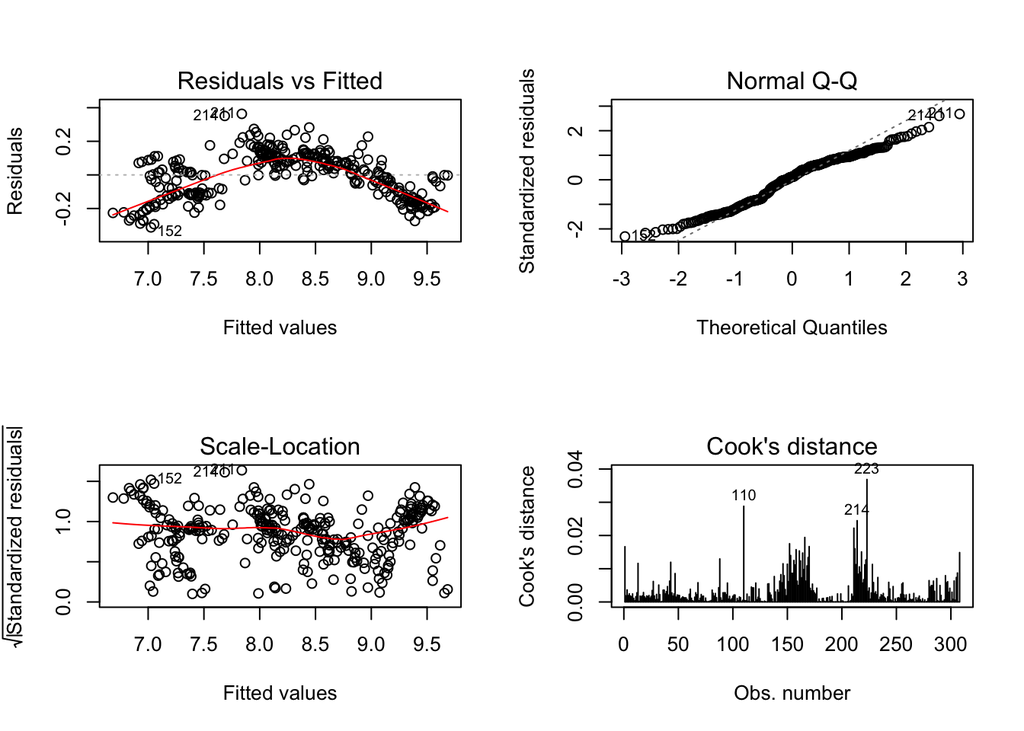

```r
par(mfrow=c(2,2))
plot(lm1, which=c(1:4), ask=F)
```

### Normality

```r
jarque.bera.test(lm1$residuals)
```

```
##
##  Jarque Bera Test
##
## data:  lm1$residuals
## X-squared = 8.0626, df = 2, p-value = 0.01775
```

Testing statistically for residual normality we find indeed that the residuals are not normally distributed. Hence, the p-value is < 0.05 and so we reject the null hypothesis stating that the data is normally distributed.

```r
outlierTest(lm1, cutoff=0.05)
```

```
## No Studentized residuals with Bonferonni p < 0.05
## Largest |rstudent|:
##     rstudent unadjusted p-value Bonferonni p
## 211 2.710409          0.0071149           NA
```

```r
jarque.bera.test(lm1$residuals[-c(211)])
```

```
##
##  Jarque Bera Test
##
## data:  lm1$residuals[-c(211)]
## X-squared = 10.445, df = 2, p-value = 0.005395
```

When we remove the one outlier detected by the outlier test, the p-value decreases even further.

### Constant variance

```r
bptest(lm1)
```

```
##
##  studentized Breusch-Pagan test
##
## data:  lm1
## BP = 47.223, df = 12, p-value = 4.265e-06
```

Testing for constant variance we find that we can reject the null hypothesis stating that the residuals are homocedastic. Hence, the test points out that we do not have constant variance in the residuals.

### Independence of the residuals

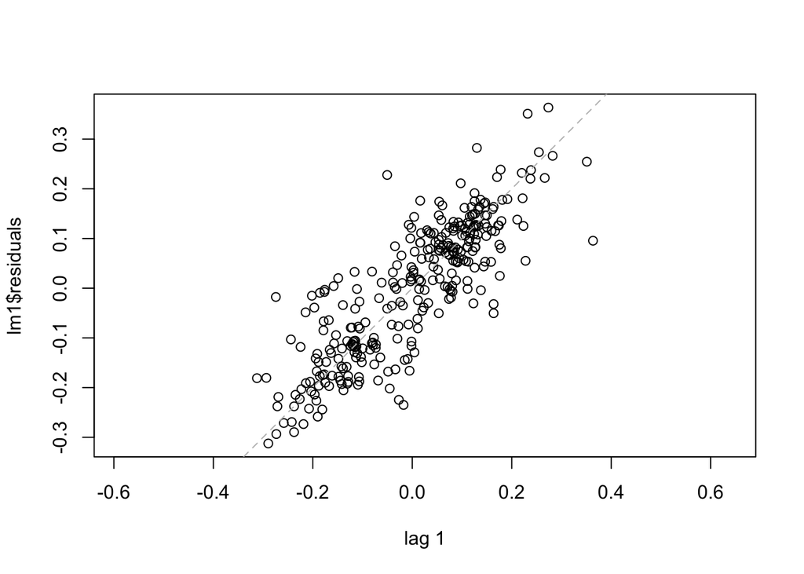

```r
lag.plot(lm1$residuals)
```

```r
dwtest(lm1)
```

```
##
##  Durbin-Watson test
##
## data:  lm1
## DW = 0.31422, p-value < 2.2e-16
## alternative hypothesis: true autocorrelation is greater than 0
```

Looking at the autocorrelation plot we assume that there is no independence in the residuals. This assumption is confirmed by the Durbin-Watson test by rejecting the null hypothesis stating that the autocorrelation of the residuals is equal to 0.

```r
diamonds <- read.table("HW-diamonds.txt", header=FALSE, col.names = c('caratage', 'color_purity', 'clarity', 'cert', 'price'))
```

## Trying two different remedial actions (Q3)

### Interaction term between cat_carat and caratage (Q3.a)

```r
#New variable cat_carat created
diamonds$cat_carat<-cut(diamonds$caratage, c(0,0.5,1,1.1))
diamonds$cat_carat <- as.character(diamonds$cat_carat)
diamonds$cat_carat[diamonds$caratage <= 0.5] <- "small"
diamonds$cat_carat[diamonds$caratage > 0.5 & diamonds$caratage <= 1] <- "medium"
diamonds$cat_carat[diamonds$caratage > 1] <- "large"
diamonds$cat_carat <- as.factor(diamonds$cat_carat)
diamonds$cat_carat = relevel(diamonds$cat_carat, ref = "small")
```

```r
lm2 = lm(formula = log(price) ~ caratage + color_purity + clarity + cert + cat_carat + caratage:cat_carat, data = diamonds)
summary(lm2)
```

```
##
## Call:
## lm(formula = log(price) ~ caratage + color_purity + clarity +
##     cert + cat_carat + caratage:cat_carat, data = diamonds)
##
## Residuals:
##       Min        1Q    Median        3Q       Max
## -0.188358 -0.031815 -0.000249  0.043143  0.140535
##
## Coefficients:
##                           Estimate Std. Error t value Pr(>|t|)
## (Intercept)               6.240808   0.028644 217.875  < 2e-16 ***
## caratage                  4.427061   0.069811  63.415  < 2e-16 ***
## color_purityE            -0.085348   0.017022  -5.014 9.29e-07 ***
## color_purityF            -0.161250   0.015995 -10.081  < 2e-16 ***
## color_purityG            -0.244812   0.016384 -14.942  < 2e-16 ***
## color_purityH            -0.325194   0.016609 -19.580  < 2e-16 ***
## color_purityI            -0.436261   0.017465 -24.979  < 2e-16 ***
## clarityVS1               -0.248263   0.013212 -18.790  < 2e-16 ***
## clarityVS2               -0.315793   0.013935 -22.662  < 2e-16 ***
## clarityVVS1              -0.102344   0.013301  -7.695 2.22e-13 ***
## clarityVVS2              -0.183420   0.012364 -14.835  < 2e-16 ***
## certHRD                  -0.005606   0.008794  -0.637   0.5243
## certIGI                  -0.023689   0.011358  -2.086   0.0379 *
## cat_caratlarge            2.340691   0.404861   5.781 1.91e-08 ***
## cat_caratmedium           1.062001   0.032653  32.523  < 2e-16 ***
## caratage:cat_caratlarge  -3.350469   0.399880  -8.379 2.31e-15 ***
## caratage:cat_caratmedium -2.047162   0.074556 -27.458  < 2e-16 ***
## ---
## Signif. codes:  0 '***' 0.001 '**' 0.01 '*' 0.05 '.' 0.1 ' ' 1
##
## Residual standard error: 0.0576 on 291 degrees of freedom
## Multiple R-squared:  0.9953, Adjusted R-squared:  0.995
## F-statistic:  3816 on 16 and 291 DF,  p-value: < 2.2e-16
```

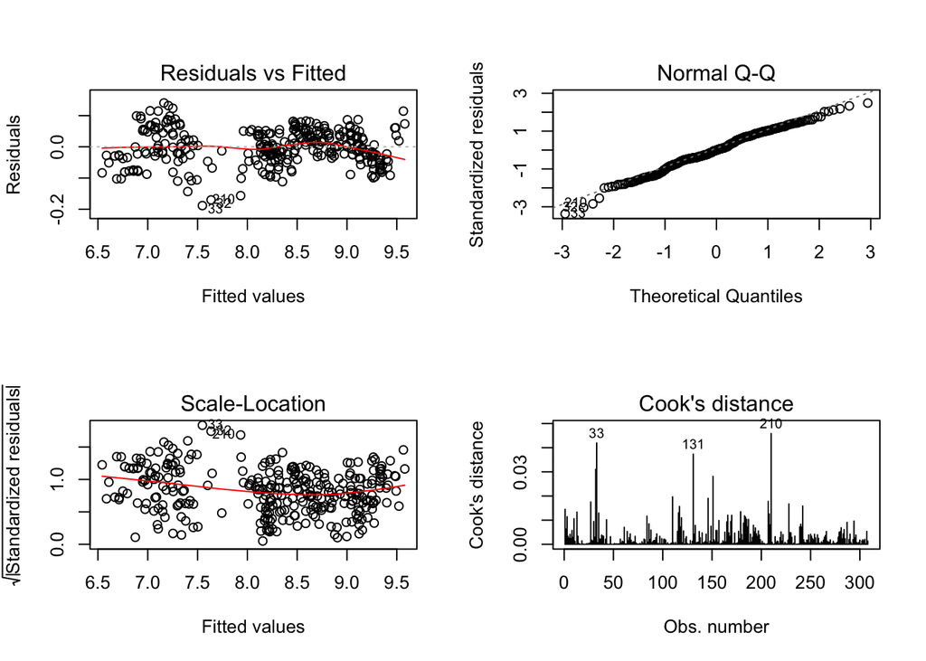

```r
par(mfrow=c(2,2))
plot(lm2, which=c(1:4), ask=F)
```

From these plots it seems like the variance isn’t constant. However, the residuals seem more normal distributed. We can have a look at the statistical test to quantify our assumptions:

```r
jarque.bera.test(lm2$residuals)
```

```
##
##  Jarque Bera Test
##
## data:  lm2$residuals
## X-squared = 3.517, df = 2, p-value = 0.1723
```

```r
bptest(lm2)
```

```
##
##  studentized Breusch-Pagan test
##
## data:  lm2
## BP = 40.256, df = 16, p-value = 0.0007143
```

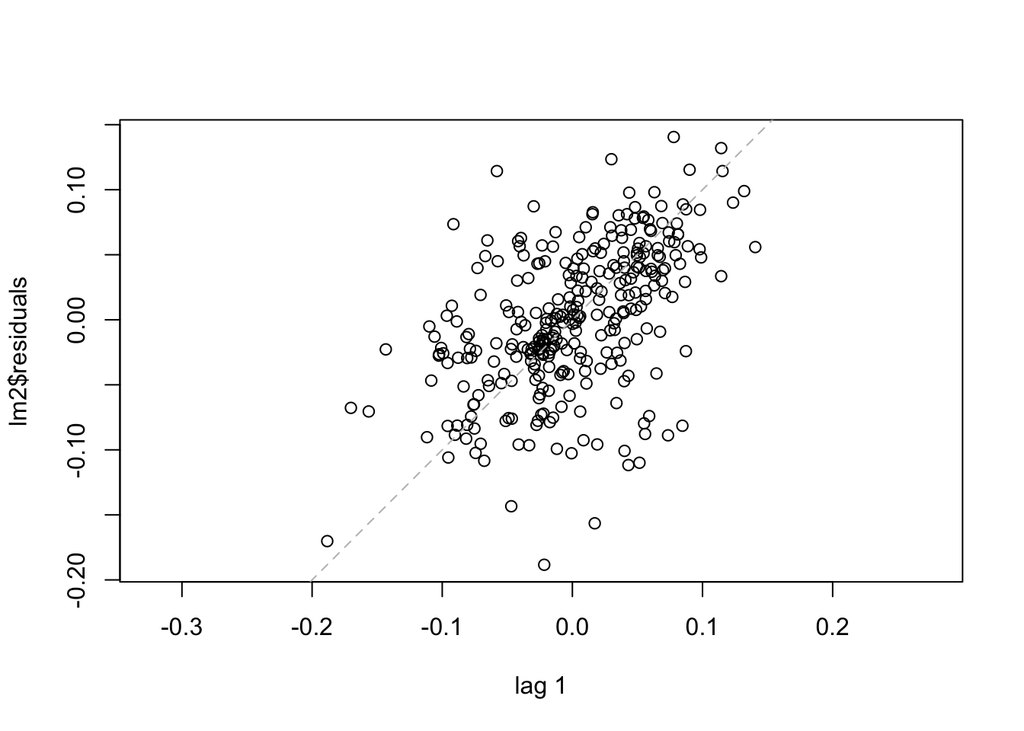

```r
lag.plot(lm2$residuals)
```

```r
dwtest(lm2)
```

```
##
##  Durbin-Watson test
##
## data:  lm2
## DW = 0.96989, p-value < 2.2e-16
## alternative hypothesis: true autocorrelation is greater than 0
```

From these tests we presume that the residuals are normally distributed, but non constant in variance and not independent.

- The regression model isn’t satisfactory since residuals don’t behave nicely. The variance isn’t constant and we some outliers (33, 32, 210).
- See with the teacher

```r
summary(lm2)
```

```
##
## Call:
## lm(formula = log(price) ~ caratage + color_purity + clarity +
##     cert + cat_carat + caratage:cat_carat, data = diamonds)
##
## Residuals:
##       Min        1Q    Median        3Q       Max
## -0.188358 -0.031815 -0.000249  0.043143  0.140535
##
## Coefficients:
##                           Estimate Std. Error t value Pr(>|t|)
## (Intercept)               6.240808   0.028644 217.875  < 2e-16 ***
## caratage                  4.427061   0.069811  63.415  < 2e-16 ***
## color_purityE            -0.085348   0.017022  -5.014 9.29e-07 ***
## color_purityF            -0.161250   0.015995 -10.081  < 2e-16 ***
## color_purityG            -0.244812   0.016384 -14.942  < 2e-16 ***
## color_purityH            -0.325194   0.016609 -19.580  < 2e-16 ***
## color_purityI            -0.436261   0.017465 -24.979  < 2e-16 ***
## clarityVS1               -0.248263   0.013212 -18.790  < 2e-16 ***
## clarityVS2               -0.315793   0.013935 -22.662  < 2e-16 ***
## clarityVVS1              -0.102344   0.013301  -7.695 2.22e-13 ***
## clarityVVS2              -0.183420   0.012364 -14.835  < 2e-16 ***
## certHRD                  -0.005606   0.008794  -0.637   0.5243
## certIGI                  -0.023689   0.011358  -2.086   0.0379 *
## cat_caratlarge            2.340691   0.404861   5.781 1.91e-08 ***
## cat_caratmedium           1.062001   0.032653  32.523  < 2e-16 ***
## caratage:cat_caratlarge  -3.350469   0.399880  -8.379 2.31e-15 ***
## caratage:cat_caratmedium -2.047162   0.074556 -27.458  < 2e-16 ***
## ---
## Signif. codes:  0 '***' 0.001 '**' 0.01 '*' 0.05 '.' 0.1 ' ' 1
##
## Residual standard error: 0.0576 on 291 degrees of freedom
## Multiple R-squared:  0.9953, Adjusted R-squared:  0.995
## F-statistic:  3816 on 16 and 291 DF,  p-value: < 2.2e-16
```

- In order to know which is more highly valued between color or clarity, we can notice that the mean for the color purity is : -0,25 whereas the mean for clarity is : -0,21. The more highly valued is clarity.

```r
diamonds$color_purity = relevel(diamonds$color_purity, ref="I")
lm2 = lm(formula = log(price) ~ caratage + color_purity + clarity + cert + cat_carat + caratage:cat_carat, data = diamonds)
summary(lm2)
```

```
##
## Call:
## lm(formula = log(price) ~ caratage + color_purity + clarity +
##     cert + cat_carat + caratage:cat_carat, data = diamonds)
##
## Residuals:
##       Min        1Q    Median        3Q       Max
## -0.188358 -0.031815 -0.000249  0.043143  0.140535
##
## Coefficients:
##                           Estimate Std. Error t value Pr(>|t|)
## (Intercept)               5.804548   0.027782 208.931  < 2e-16 ***
## caratage                  4.427061   0.069811  63.415  < 2e-16 ***
## color_purityD             0.436261   0.017465  24.979  < 2e-16 ***
## color_purityE             0.350912   0.012927  27.146  < 2e-16 ***
## color_purityF             0.275010   0.011535  23.841  < 2e-16 ***
## color_purityG             0.191449   0.011869  16.131  < 2e-16 ***
## color_purityH             0.111067   0.011923   9.316  < 2e-16 ***
## clarityVS1               -0.248263   0.013212 -18.790  < 2e-16 ***
## clarityVS2               -0.315793   0.013935 -22.662  < 2e-16 ***
## clarityVVS1              -0.102344   0.013301  -7.695 2.22e-13 ***
## clarityVVS2              -0.183420   0.012364 -14.835  < 2e-16 ***
## certHRD                  -0.005606   0.008794  -0.637   0.5243
## certIGI                  -0.023689   0.011358  -2.086   0.0379 *
## cat_caratlarge            2.340691   0.404861   5.781 1.91e-08 ***
## cat_caratmedium           1.062001   0.032653  32.523  < 2e-16 ***
## caratage:cat_caratlarge  -3.350469   0.399880  -8.379 2.31e-15 ***
## caratage:cat_caratmedium -2.047162   0.074556 -27.458  < 2e-16 ***
## ---
## Signif. codes:  0 '***' 0.001 '**' 0.01 '*' 0.05 '.' 0.1 ' ' 1
##
## Residual standard error: 0.0576 on 291 degrees of freedom
## Multiple R-squared:  0.9953, Adjusted R-squared:  0.995
## F-statistic:  3816 on 16 and 291 DF,  p-value: < 2.2e-16
```

```r
diamonds$color_purity = relevel(diamonds$color_purity, ref="E")
lm2 = lm(formula = log(price) ~ caratage + color_purity + clarity + cert + cat_carat + caratage:cat_carat, data = diamonds)
summary(lm2)
```

```
##
## Call:
## lm(formula = log(price) ~ caratage + color_purity + clarity +
##     cert + cat_carat + caratage:cat_carat, data = diamonds)
##
## Residuals:
##       Min        1Q    Median        3Q       Max
## -0.188358 -0.031815 -0.000249  0.043143  0.140535
##
## Coefficients:
##                           Estimate Std. Error t value Pr(>|t|)
## (Intercept)               6.155460   0.027511 223.744  < 2e-16 ***
## caratage                  4.427061   0.069811  63.415  < 2e-16 ***
## color_purityI            -0.350912   0.012927 -27.146  < 2e-16 ***
## color_purityD             0.085348   0.017022   5.014 9.29e-07 ***
## color_purityF            -0.075902   0.010844  -6.999 1.78e-11 ***
## color_purityG            -0.159463   0.011430 -13.952  < 2e-16 ***
## color_purityH            -0.239846   0.011624 -20.633  < 2e-16 ***
## clarityVS1               -0.248263   0.013212 -18.790  < 2e-16 ***
## clarityVS2               -0.315793   0.013935 -22.662  < 2e-16 ***
## clarityVVS1              -0.102344   0.013301  -7.695 2.22e-13 ***
## clarityVVS2              -0.183420   0.012364 -14.835  < 2e-16 ***
## certHRD                  -0.005606   0.008794  -0.637   0.5243
## certIGI                  -0.023689   0.011358  -2.086   0.0379 *
## cat_caratlarge            2.340691   0.404861   5.781 1.91e-08 ***
## cat_caratmedium           1.062001   0.032653  32.523  < 2e-16 ***
## caratage:cat_caratlarge  -3.350469   0.399880  -8.379 2.31e-15 ***
## caratage:cat_caratmedium -2.047162   0.074556 -27.458  < 2e-16 ***
## ---
## Signif. codes:  0 '***' 0.001 '**' 0.01 '*' 0.05 '.' 0.1 ' ' 1
##
## Residual standard error: 0.0576 on 291 degrees of freedom
## Multiple R-squared:  0.9953, Adjusted R-squared:  0.995
## F-statistic:  3816 on 16 and 291 DF,  p-value: < 2.2e-16
```

```r
diamonds$cert = relevel(diamonds$cert, ref="HRD")
lm2 = lm(formula = log(price) ~ caratage + color_purity + clarity + cert + cat_carat + caratage:cat_carat, data = diamonds)
summary(lm2)
```

```
##
## Call:
## lm(formula = log(price) ~ caratage + color_purity + clarity +
##     cert + cat_carat + caratage:cat_carat, data = diamonds)
##
## Residuals:
##       Min        1Q    Median        3Q       Max
## -0.188358 -0.031815 -0.000249  0.043143  0.140535
##
## Coefficients:
##                           Estimate Std. Error t value Pr(>|t|)
## (Intercept)               6.149854   0.028003 219.614  < 2e-16 ***
## caratage                  4.427061   0.069811  63.415  < 2e-16 ***
## color_purityI            -0.350912   0.012927 -27.146  < 2e-16 ***
## color_purityD             0.085348   0.017022   5.014 9.29e-07 ***
## color_purityF            -0.075902   0.010844  -6.999 1.78e-11 ***
## color_purityG            -0.159463   0.011430 -13.952  < 2e-16 ***
## color_purityH            -0.239846   0.011624 -20.633  < 2e-16 ***
## clarityVS1               -0.248263   0.013212 -18.790  < 2e-16 ***
## clarityVS2               -0.315793   0.013935 -22.662  < 2e-16 ***
## clarityVVS1              -0.102344   0.013301  -7.695 2.22e-13 ***
## clarityVVS2              -0.183420   0.012364 -14.835  < 2e-16 ***
## certGIA                   0.005606   0.008794   0.637    0.524
## certIGI                  -0.018082   0.012684  -1.426    0.155
## cat_caratlarge            2.340691   0.404861   5.781 1.91e-08 ***
## cat_caratmedium           1.062001   0.032653  32.523  < 2e-16 ***
## caratage:cat_caratlarge  -3.350469   0.399880  -8.379 2.31e-15 ***
## caratage:cat_caratmedium -2.047162   0.074556 -27.458  < 2e-16 ***
## ---
## Signif. codes:  0 '***' 0.001 '**' 0.01 '*' 0.05 '.' 0.1 ' ' 1
##
## Residual standard error: 0.0576 on 291 degrees of freedom
## Multiple R-squared:  0.9953, Adjusted R-squared:  0.995
## F-statistic:  3816 on 16 and 291 DF,  p-value: < 2.2e-16
```

```r
diamonds$cert = relevel(diamonds$cert, ref="GIA")
lm2 = lm(formula = log(price) ~ caratage + color_purity + clarity + cert + cat_carat + caratage:cat_carat, data = diamonds)
summary(lm2)
```

```
##
## Call:
## lm(formula = log(price) ~ caratage + color_purity + clarity +
##     cert + cat_carat + caratage:cat_carat, data = diamonds)
##
## Residuals:
##       Min        1Q    Median        3Q       Max
## -0.188358 -0.031815 -0.000249  0.043143  0.140535
##
## Coefficients:
##                           Estimate Std. Error t value Pr(>|t|)
## (Intercept)               6.155460   0.027511 223.744  < 2e-16 ***
## caratage                  4.427061   0.069811  63.415  < 2e-16 ***
## color_purityI            -0.350912   0.012927 -27.146  < 2e-16 ***
## color_purityD             0.085348   0.017022   5.014 9.29e-07 ***
## color_purityF            -0.075902   0.010844  -6.999 1.78e-11 ***
## color_purityG            -0.159463   0.011430 -13.952  < 2e-16 ***
## color_purityH            -0.239846   0.011624 -20.633  < 2e-16 ***
## clarityVS1               -0.248263   0.013212 -18.790  < 2e-16 ***
## clarityVS2               -0.315793   0.013935 -22.662  < 2e-16 ***
## clarityVVS1              -0.102344   0.013301  -7.695 2.22e-13 ***
## clarityVVS2              -0.183420   0.012364 -14.835  < 2e-16 ***
## certHRD                  -0.005606   0.008794  -0.637   0.5243
## certIGI                  -0.023689   0.011358  -2.086   0.0379 *
## cat_caratlarge            2.340691   0.404861   5.781 1.91e-08 ***
## cat_caratmedium           1.062001   0.032653  32.523  < 2e-16 ***
## caratage:cat_caratlarge  -3.350469   0.399880  -8.379 2.31e-15 ***
## caratage:cat_caratmedium -2.047162   0.074556 -27.458  < 2e-16 ***
## ---
## Signif. codes:  0 '***' 0.001 '**' 0.01 '*' 0.05 '.' 0.1 ' ' 1
##
## Residual standard error: 0.0576 on 291 degrees of freedom
## Multiple R-squared:  0.9953, Adjusted R-squared:  0.995
## F-statistic:  3816 on 16 and 291 DF,  p-value: < 2.2e-16
```

```r
diamonds$cert = relevel(diamonds$cert, ref="IGI")
lm2 = lm(formula = log(price) ~ caratage + color_purity + clarity + cert + cat_carat + caratage:cat_carat, data = diamonds)
summary(lm2)
```

```
##
## Call:
## lm(formula = log(price) ~ caratage + color_purity + clarity +
##     cert + cat_carat + caratage:cat_carat, data = diamonds)
##
## Residuals:
##       Min        1Q    Median        3Q       Max
## -0.188358 -0.031815 -0.000249  0.043143  0.140535
##
## Coefficients:
##                          Estimate Std. Error t value Pr(>|t|)
## (Intercept)               6.13177    0.02233 274.610  < 2e-16 ***
## caratage                  4.42706    0.06981  63.415  < 2e-16 ***
## color_purityI            -0.35091    0.01293 -27.146  < 2e-16 ***
## color_purityD             0.08535    0.01702   5.014 9.29e-07 ***
## color_purityF            -0.07590    0.01084  -6.999 1.78e-11 ***
## color_purityG            -0.15946    0.01143 -13.952  < 2e-16 ***
## color_purityH            -0.23985    0.01162 -20.633  < 2e-16 ***
## clarityVS1               -0.24826    0.01321 -18.790  < 2e-16 ***
## clarityVS2               -0.31579    0.01393 -22.662  < 2e-16 ***
## clarityVVS1              -0.10234    0.01330  -7.695 2.22e-13 ***
## clarityVVS2              -0.18342    0.01236 -14.835  < 2e-16 ***
## certGIA                   0.02369    0.01136   2.086   0.0379 *
## certHRD                   0.01808    0.01268   1.426   0.1551
## cat_caratlarge            2.34069    0.40486   5.781 1.91e-08 ***
## cat_caratmedium           1.06200    0.03265  32.523  < 2e-16 ***
## caratage:cat_caratlarge  -3.35047    0.39988  -8.379 2.31e-15 ***
## caratage:cat_caratmedium -2.04716    0.07456 -27.458  < 2e-16 ***
## ---
## Signif. codes:  0 '***' 0.001 '**' 0.01 '*' 0.05 '.' 0.1 ' ' 1
##
## Residual standard error: 0.0576 on 291 degrees of freedom
## Multiple R-squared:  0.9953, Adjusted R-squared:  0.995
## F-statistic:  3816 on 16 and 291 DF,  p-value: < 2.2e-16
```

### Squared carat (Q 3b)

Let us see what happens if we include the squared caratage in the linear model.

```r
lm3 = lm(formula = log(price) ~ caratage + I(caratage^2) + color_purity + clarity + cert, data = diamonds)
summary(lm3)
```

```
##
## Call:
## lm(formula = log(price) ~ caratage + I(caratage^2) + color_purity +
##     clarity + cert, data = diamonds)
##
## Residuals:
##      Min       1Q   Median       3Q      Max
## -0.15411 -0.04120 -0.00911  0.04543  0.14158
##
## Coefficients:
##               Estimate Std. Error t value Pr(>|t|)
## (Intercept)    5.97069    0.02169 275.252  < 2e-16 ***
## caratage       5.67062    0.07928  71.523  < 2e-16 ***
## I(caratage^2) -2.10292    0.05802 -36.243  < 2e-16 ***
## color_purityI -0.36336    0.01322 -27.485  < 2e-16 ***
## color_purityD  0.07925    0.01739   4.558 7.59e-06 ***
## color_purityF -0.07674    0.01114  -6.888 3.44e-11 ***
## color_purityG -0.16579    0.01173 -14.131  < 2e-16 ***
## color_purityH -0.25985    0.01191 -21.816  < 2e-16 ***
## clarityVS1    -0.24447    0.01336 -18.301  < 2e-16 ***
## clarityVS2    -0.32018    0.01428 -22.424  < 2e-16 ***
## clarityVVS1   -0.09401    0.01357  -6.926 2.74e-11 ***
## clarityVVS2   -0.17670    0.01259 -14.032  < 2e-16 ***
## certGIA        0.02541    0.01154   2.203   0.0284 *
## certHRD        0.01919    0.01300   1.476   0.1411
## ---
## Signif. codes:  0 '***' 0.001 '**' 0.01 '*' 0.05 '.' 0.1 ' ' 1
##
## Residual standard error: 0.0592 on 294 degrees of freedom
## Multiple R-squared:  0.9949, Adjusted R-squared:  0.9947
## F-statistic:  4445 on 13 and 294 DF,  p-value: < 2.2e-16
```

From the summary we see that the squared caratage is actually of significance for the model. Let us have a look at the model plots.

### Model plots

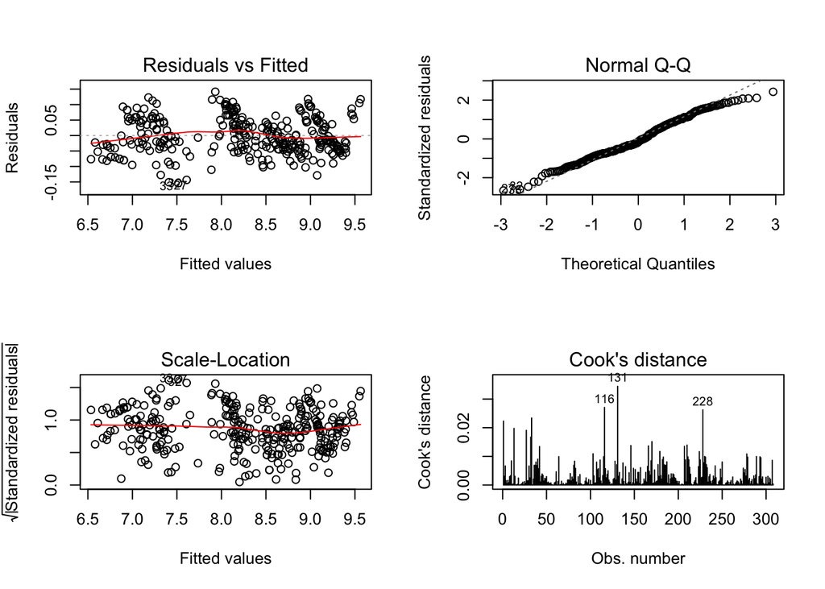

```r
par(mfrow=c(2,2))
plot(lm3, which=c(1:4), ask=F)
```

From these plots it looks at least like the variance is constant. Also, the residuals seem more normal distributed, but it is unclear from the plot whether it really is. Let us look at the statistical test to quantify our assumptions.

### Statistical tests

```r
jarque.bera.test(lm3$residuals)
```

```
##
##  Jarque Bera Test
##
## data:  lm3$residuals
## X-squared = 3.8901, df = 2, p-value = 0.143
```

```r
bptest(lm3)
```

```
##
##  studentized Breusch-Pagan test
##
## data:  lm3
## BP = 16.094, df = 13, p-value = 0.2441
```

```r
dwtest(lm3)
```

```
##
##  Durbin-Watson test
##
## data:  lm3
## DW = 0.98039, p-value < 2.2e-16
## alternative hypothesis: true autocorrelation is greater than 0
```

From these tests we presume that the residuals are normally distributed, constant in variance, but not independent.

## Comparing remedial actions (Q4)

Looking at both remdial actions we note that both improve the validity of the assumptions. Namely, in both cases the residuals are now normally distributed. However, adding the squared caratage also improves the constant variance assumption, while adding the clustered caratage groups does not. Hence, we have a better model fit in the squared caratage case.

On the other hand, adding a squared term to the model complicates its interpretability. For example, in this case, when the caratage raises by one point, the price increases `exp(5.671)=290` times, while increasing the squared caratage by one point increases the price `exp(-2.103)=0.122` times (i.e. decreases 88%). This makes it hard to assess the influence of the caratage on the price.

The conclusion is that the comparison of the remedial actions is a comparison of model fit vs. interpretability. How this trade-off should be made depends on the application of the regression model. Since we are trying to educate laypeople, we believe that interpretability should be valued higher in this case. Therefore, we prefer the first remedial action.